# Jupyter Notebooks

#### DataFrame Information

Also, especially when working with a new large data set, it is best practice to print out the **Information Document** to keep as a visual reference.

Running the command `.info()` provides essential details about the data set such as the number of rows and columns, the number of non-null values, what type of data is in each column, and how much memory your DataFrame is using.

**See example below:**

```python
dfData1.info()
```

```
<class 'pandas.core.frame.DataFrame'>
DatetimeIndex: 6 entries, 2019-01-01 to 2019-01-06
Freq: D
Data columns (total 4 columns):
A    6 non-null float64
B    6 non-null float64
C    6 non-null float64
D    6 non-null float64
dtypes: float64(4)
memory usage: 400.0 bytes
```

Alternatively, some details in the data set can be called individually.

These attributes include:

- `.index` will list the Index values
- `.shape` outputs a tuple of (rows, columns)
- `.dtypes` will list the datatypes in force
- `.columns` will list the Column labels and overall datatype

**See examples below:**

```python
dfData1.index
```

```
DatetimeIndex(['2019-01-01', '2019-01-02', '2019-01-03', '2019-01-04',
               '2019-01-05', '2019-01-06'],
              dtype='datetime64[ns]', freq='D')
```

```python
dfData1.shape
```

```
(6, 4)
```

```python
dfData1.dtypes
```

```
A    float64
B    float64
C    float64
D    float64
dtype: object
```

```python
dfData1.columns
```

```
Index(['A', 'B', 'C', 'D'], dtype='object')
```

#### DataFrame Statistics

It may be useful when working with a new large data set to create a quick **Statistical Summary** of the data set to also keep as a visual reference.

Running the command `.describe()` provides for the analysis of numeric data. The resulting index will include count, mean, std, min, max as well as lower, 50 and upper percentiles. By default, the lower percentile is 25 and the upper percentile is 75. The 50 percentile is the same as the median.

For object data (e.g. strings or timestamps), the resulting index will include count, unique, top, and freq. The top is the most common value. The freq is the most common value’s frequency. Timestamps also include the first and last items.

If multiple object values have the highest count, then the count and top results will be arbitrarily chosen from among those with the highest count.

**See example below:**

```python
dfData1.describe()
```

|  | A | B | C | D |
| --- | --- | --- | --- | --- |
| count | 6.000000 | 6.000000 | 6.000000 | 6.000000 |
| mean | 0.145945 | 0.253098 | 0.455794 | 0.368067 |
| std | 0.364792 | 0.909241 | 1.492291 | 0.988672 |
| min | -0.489581 | -0.755912 | -1.804682 | -0.830140 |
| 25% | 0.025924 | -0.517771 | -0.227926 | -0.084960 |
| 50% | 0.228880 | 0.183194 | 0.416599 | 0.190135 |
| 75% | 0.369054 | 1.074315 | 1.422534 | 0.599070 |
| max | 0.533439 | 1.288184 | 2.391173 | 2.099550 |

Alternatively, some statistics for the data set can be called individually.

These attributes include:

- `.count()` returns the number of non-null observations
- `.sum()` returns the sum of the values
- `.mean()` returns the mean of the values
- `.median()` returns the median of values
- `.mode()` returns the mode of values
- `.std()` returns the Standard Deviation of the values
- `.min()` returns the minimum value
- `.max()` returns the maximum value
- `.abs()` returns the Absolute value
- `.prod()` returns the product of values
- `.cumsum()` returns the cumulative Sum
- `.cumprod()` returns the cumulative Product

**See some examples below:**

```python
sSecond = pd.Series(np.random.randint(0, 7, size=10))
sSecond
```

```
0    3
1    5
2    6
3    1
4    4
5    0
6    6
7    3
8    4
9    6
dtype: int32
```

```python
# As a Series of Integers has been created, it is possible to count the occurance of each value

sSecond.value_counts()
```

```
6    3
4    2
3    2
5    1
1    1
0    1
dtype: int64
```

```python
dfData1.count()
```

```
A    6
B    6
C    6
D    6
dtype: int64
```

```python
dfData1.mean()
```

```
A    0.145945
B    0.253098
C    0.455794
D    0.368067
dtype: float64
```

```python
#same operation on the other axis

dfData1.mean(1)
```

```
2019-01-01    0.089093
2019-01-02    0.295692
2019-01-03   -0.816225
2019-01-04    0.836299
2019-01-05    0.421426
2019-01-06    1.008072
Freq: D, dtype: float64
```

pandas also facilitates calling only the **values of the data set** as an array.

**See example below:**

```python
dfData1.values
```

```
array([[-0.01886229,  0.50688393,  0.00293113, -0.13458234],
       [ 0.16028167,  1.26345862, -0.30487903,  0.0639065 ],
       [-0.48958128, -0.14049518, -1.80468158, -0.83014041],
       [ 0.53343927,  1.28818425,  0.83026639,  0.69330477],
       [ 0.39291198, -0.64353012,  1.61995702,  0.31636386],
       [ 0.29747917, -0.7559124 ,  2.39117305,  2.09954998]])
```

### Selection by Indexing

As a DataFrame is a two-dimensional data structure (data is aligned as a table in rows and columns), it is possible to perform basic operations on the rows/columns like selecting, deleting, adding, and renaming.

pandas DataFrames support familiar Python expressions for selecting and setting elements using subscripts `[]` and slicing. In pandas, Indexing facilitates selecting particular rows and columns of data from a DataFrame. Indexing can also be known as Subset Selection.

pandas offers 4 methods for selection by Indexing:

by Label

- `.at` and `.loc` both provide name-based indexing
- `.at` provides faster indexing for a single element
- `.loc` can slice more than one element

by Position

- `.iat` and `.iloc` both provide integer-based indexing
- `.iat` provides indexing for a single element
- `.iloc` can slice more than one element

pandas Syntax for `loc` and `iloc`:

The Indexing operator is used to refer to the braces `[]` following an object.

- for a Series: `s.loc[indexer]`
- for a DataFrame: `df.loc[row_indexer,column_indexer]`

#### Selection by Label

##### Column Selection by Label

**See examples below:** Notice that all rows in the DataFrame are returned, with column label slicing presented.

```python
dfData2["EndValue"]
```

```
0    1.0
1    1.0
2    1.0
3    1.0
Name: EndValue, dtype: float32
```

```python
dfData2[['StartValue','EndValue']]
```

|  | StartValue | EndValue |
| --- | --- | --- |
| 0 | 1.0 | 1.0 |
| 1 | 1.0 | 1.0 |
| 2 | 1.0 | 1.0 |
| 3 | 1.0 | 1.0 |

##### Row Selection by Label

**See example below:** Notice that all columns in the DataFrame are returned, with row label slicing presented. In this example: Those rows on with Index values 2 and 3

```python
dfData2.loc[2:3]
```

|  | StartValue | StartDate | EndValue | Activity | Action | Response |
| --- | --- | --- | --- | --- | --- | --- |
| 2 | 1.0 | 2019-01-02 | 1.0 | 3 | test | foo |
| 3 | 1.0 | 2019-01-02 | 1.0 | 3 | train | foo |

##### Multi-Axis Selection by Label

**See example below:** Notice all rows requested with column label slicing. In this example: Remember that A and B are column labels in the DataFrame dfData1, not column positions.

```python
dfData1.loc[:,['A','B']]
```

|  | A | B |
| --- | --- | --- |
| 2019-01-01 | -0.018862 | 0.506884 |
| 2019-01-02 | 0.160282 | 1.263459 |
| 2019-01-03 | -0.489581 | -0.140495 |
| 2019-01-04 | 0.533439 | 1.288184 |
| 2019-01-05 | 0.392912 | -0.643530 |
| 2019-01-06 | 0.297479 | -0.755912 |

In this example: Now showing row and column label slicing, with both endpoints included:

```python
dfData1.loc['20190102':'20190104',['A','B']]
```

|  | A | B |
| --- | --- | --- |
| 2019-01-02 | 0.160282 | 1.263459 |
| 2019-01-03 | -0.489581 | -0.140495 |
| 2019-01-04 | 0.533439 | 1.288184 |

In this example: It is possible to offer a reduction in the dimensions of the returned object:

```python
dfData1.loc['20190102',['A','B']]
```

```
A    0.160282
B    1.263459
Name: 2019-01-02 00:00:00, dtype: float64
```

In pandas, a **scalar value** includes:

- numpy array scalar (e.g. np.int64)
- Python builtin numerics
- Python builtin byte arrays and strings
- None
- datetime.datetime
- datetime.timedelta
- Period
- decimal.Decimal
- Interval
- DateOffset
- Fraction
- Number

**See example below:** In this example: A scalar value is being specifically called from the `df` DataFrame, in the first row, under the column labelled: A

```python
dfData1.loc[dates[0],'A']
```

```
-0.018862294063333215
```

pandas offers faster access to a scalar value (equivalent to the prior method) by making use of `.at`

**See example below:**

```python
dfData1.at[dates[0],'A']
```

```
-0.018862294063333215
```

#### Selection by Position

##### Row Selection by Position

**See examples below:** Notice that all columns in the DataFrame are returned, with row slicing presented. In this example: The rows on the lines between 0 (inclusive) and less than 3 are presented.

```python
dfData1[0:3]
```

|  | A | B | C | D |
| --- | --- | --- | --- | --- |
| 2019-01-01 | -0.018862 | 0.506884 | 0.002931 | -0.134582 |
| 2019-01-02 | 0.160282 | 1.263459 | -0.304879 | 0.063906 |
| 2019-01-03 | -0.489581 | -0.140495 | -1.804682 | -0.830140 |

In this example: The row on the specific third line is presented.

```python
dfData1.iloc[3]
```

```
A    0.533439
B    1.288184
C    0.830266
D    0.693305
Name: 2019-01-04 00:00:00, dtype: float64
```

##### Multi-Axis Selection by Position

**See examples below:** By Integer slices, acting similar to numpy/python.

```python
dfData1.iloc[3:5,0:2]
```

|  | A | B |
| --- | --- | --- |
| 2019-01-04 | 0.533439 | 1.288184 |
| 2019-01-05 | 0.392912 | -0.643530 |

In this example: By lists of Integer position locations, similar to the numpy/python style:

```python
dfData1.iloc[[1,2,4],[0,2]]
```

|  | A | C |
| --- | --- | --- |
| 2019-01-02 | 0.160282 | -0.304879 |
| 2019-01-03 | -0.489581 | -1.804682 |
| 2019-01-05 | 0.392912 | 1.619957 |

In this example: For slicing rows explicitly

```python
dfData1.iloc[1:3,:]
```

|  | A | B | C | D |
| --- | --- | --- | --- | --- |
| 2019-01-02 | 0.160282 | 1.263459 | -0.304879 | 0.063906 |
| 2019-01-03 | -0.489581 | -0.140495 | -1.804682 | -0.830140 |

In this example: For slicing columns explicitly

```python
dfData1.iloc[:,1:3]
```

|  | B | C |
| --- | --- | --- |
| 2019-01-01 | 0.506884 | 0.002931 |
| 2019-01-02 | 1.263459 | -0.304879 |
| 2019-01-03 | -0.140495 | -1.804682 |
| 2019-01-04 | 1.288184 | 0.830266 |
| 2019-01-05 | -0.643530 | 1.619957 |
| 2019-01-06 | -0.755912 | 2.391173 |

**See example below:** A scalar value is being specifically called from the `df` DataFrame, in the second row, under the second column

```python
dfData1.iloc[1,1]
```

```
1.2634586203510898
```

pandas offers faster access to a scalar value (equivalent to the prior method) by making use of `.iat`

**See example below:**

```python
dfData1.iat[1,1]
```

```
1.2634586203510898
```

#### Selection by Boolean Indexing

With Boolean Indexing, it is possible to select subsets of data based on the actual values of the data in the DataFrame and not on their row/column Labels or Position.

A Boolean vector is used to filter the data.

**See examples below:** In this example: A single column has been identified in the DataFrame, with a request for the result to only present the values greater than zero.

```python
dfData1[dfData1.A > 0]
```

|  | A | B | C | D |
| --- | --- | --- | --- | --- |
| 2019-01-02 | 0.160282 | 1.263459 | -0.304879 | 0.063906 |
| 2019-01-04 | 0.533439 | 1.288184 | 0.830266 | 0.693305 |
| 2019-01-05 | 0.392912 | -0.643530 | 1.619957 | 0.316364 |
| 2019-01-06 | 0.297479 | -0.755912 | 2.391173 | 2.099550 |

In this example: All values from the DataFrame have been requested where the Boolean condition has been met

```python
dfData1[dfData1 <= 0]
```

[output not shown]

In this example: Again, a single column has been identified in the DataFrame, but with a request for the result to only present matching the given String values by using `.isin()`

```python
dfData2[dfData2['Action'].isin(['train'])]
```

|  | StartValue | StartDate | EndValue | Activity | Action | Response |
| --- | --- | --- | --- | --- | --- | --- |
| 1 | 1.0 | 2019-01-02 | 1.0 | 3 | train | foo |
| 3 | 1.0 | 2019-01-02 | 1.0 | 3 | train | foo |

### Setting

pandas provides various facilities for the combining of Series, DataFrame, and Panel objects - as well as the replacing of data values - with varying set logic for the indexes and relational algebra functionality in the case of join/merge-type operations.

#### Adding

It is important to always ensure that when setting a new column that the list matches the number of items already present in the Indexes as setting a new column will automatically be aligned by the Indexes.

**See examples below:**

```python
# An extra Series, with the Label E is being added to a copy of DataFrame dfData1

dfData3 = dfData1.copy()
dfData3['E'] = ['one', 'one','two','three','three','four']
dfData3
```

[output not shown]

```python
# An extra Series of Integer starting at 1 and ending at 6 (inclusive) is being created

sThird = pd.Series([1,2,3,4,5,6], index=pd.date_range('20190102', periods=6))
sThird
```

```
2019-01-02    1
2019-01-03    2
2019-01-04    3
2019-01-05    4
2019-01-06    5
2019-01-07    6
Freq: D, dtype: int64
```

```python
# This extra Series of Integer, with the Label F is being set in the DataFrame df

dfData3['F'] = sThird
dfData3
```

|  | A | B | C | D | E | F |
| --- | --- | --- | --- | --- | --- | --- |
| 2019-01-01 | -0.018862 | 0.506884 | 0.002931 | -0.134582 | one | NaN |
| 2019-01-02 | 0.160282 | 1.263459 | -0.304879 | 0.063906 | one | 1.0 |
| 2019-01-03 | -0.489581 | -0.140495 | -1.804682 | -0.830140 | two | 2.0 |
| 2019-01-04 | 0.533439 | 1.288184 | 0.830266 | 0.693305 | three | 3.0 |
| 2019-01-05 | 0.392912 | -0.643530 | 1.619957 | 0.316364 | three | 4.0 |
| 2019-01-06 | 0.297479 | -0.755912 | 2.391173 | 2.099550 | four | 5.0 |

#### Replacing

Replacing of values may be done by referencing values by Label and/or by Position.

**See examples below:**

```python
# Looking at the DataFrame dfData3 and identifying the first row by the DateRange Index,
# the value in the column with the Label A
# is being replaced by 0

dfData3.at[dates[0],'A'] = 0
```

```python
# Looking at the DataFrame dfData3 and identifying the first row
# and the second column, both by position,
# the value is being replaced by 0

dfData3.iat[0,1] = 0
```

```python
# Looking at the DataFrame dfData3 and identifying the column with the Label D
# the values in all rows are being replaced by the results of assigning a NumPy array

dfData3.loc[:,'D'] = np.array([5] * len(dfData3))
```

```python
# The df is now called by name to display the results of the prior setting operations

dfData3
```

|  | A | B | C | D | E | F |
| --- | --- | --- | --- | --- | --- | --- |
| 2019-01-01 | 0.000000 | 0.000000 | 0.002931 | 5 | one | NaN |
| 2019-01-02 | 0.160282 | 1.263459 | -0.304879 | 5 | one | 1.0 |
| 2019-01-03 | -0.489581 | -0.140495 | -1.804682 | 5 | two | 2.0 |
| 2019-01-04 | 0.533439 | 1.288184 | 0.830266 | 5 | three | 3.0 |
| 2019-01-05 | 0.392912 | -0.643530 | 1.619957 | 5 | three | 4.0 |
| 2019-01-06 | 0.297479 | -0.755912 | 2.391173 | 5 | four | 5.0 |

```python
# In this example: A Dataframe dfData7 is created with 5 columns, and the data loaded

dfData7 = pd.DataFrame({'Unit': [1, 2, 3, 4 , 5 , 6],
                    'Qty': [100, 200, 300, 400, 500, 600],
                    'Test1' : [1,2,1,2,1,2],
                    'Test2' : [4,6,4,6,4,6],
                    'Test3' : [3,5,3,5,3,5]
                   })

dfData7
```

|  | Unit | Qty | Test1 | Test2 | Test3 |
| --- | --- | --- | --- | --- | --- |
| 0 | 1 | 100 | 1 | 4 | 3 |
| 1 | 2 | 200 | 2 | 6 | 5 |
| 2 | 3 | 300 | 1 | 4 | 3 |
| 3 | 4 | 400 | 2 | 6 | 5 |
| 4 | 5 | 500 | 1 | 4 | 3 |
| 5 | 6 | 600 | 2 | 6 | 5 |

```python
# In this example: The DataFrame dfData7 is copied
# and all values in the new DataFrame dfData8 that were greater than zero are set as negative numbers

dfData8=dfData7.copy()
dfData8[dfData8 > 0] = -dfData8
dfData8
```

|  | Unit | Qty | Test1 | Test2 | Test3 |
| --- | --- | --- | --- | --- | --- |
| 0 | -1 | -100 | -1 | -4 | -3 |
| 1 | -2 | -200 | -2 | -6 | -5 |
| 2 | -3 | -300 | -1 | -4 | -3 |
| 3 | -4 | -400 | -2 | -6 | -5 |
| 4 | -5 | -500 | -1 | -4 | -3 |
| 5 | -6 | -600 | -2 | -6 | -5 |

```python
# For interest, it is possible to remove duplicates rather than replace their values

# First, a new DataFrame of duplicate data values needs to created
dfData8a=dfData8.copy()
dfData8b=dfData8.copy()
dfFrames2 = [dfData8, dfData8a, dfData8b]
dfData8Copy = pd.concat(dfFrames2, sort=True)
#dfData8Copy.shape
dfData8Copy
```

|  | Qty | Test1 | Test2 | Test3 | Unit |
| --- | --- | --- | --- | --- | --- |
| 0 | -100 | -1 | -4 | -3 | -1 |
| 1 | -200 | -2 | -6 | -5 | -2 |
| 2 | -300 | -1 | -4 | -3 | -3 |
| 3 | -400 | -2 | -6 | -5 | -4 |
| 4 | -500 | -1 | -4 | -3 | -5 |
| 5 | -600 | -2 | -6 | -5 | -6 |
| 0 | -100 | -1 | -4 | -3 | -1 |
| 1 | -200 | -2 | -6 | -5 | -2 |
| 2 | -300 | -1 | -4 | -3 | -3 |
| 3 | -400 | -2 | -6 | -5 | -4 |
| 4 | -500 | -1 | -4 | -3 | -5 |
| 5 | -600 | -2 | -6 | -5 | -6 |
| 0 | -100 | -1 | -4 | -3 | -1 |
| 1 | -200 | -2 | -6 | -5 | -2 |
| 2 | -300 | -1 | -4 | -3 | -3 |
| 3 | -400 | -2 | -6 | -5 | -4 |
| 4 | -500 | -1 | -4 | -3 | -5 |
| 5 | -600 | -2 | -6 | -5 | -6 |

```python
# Next, the duplicates will be removed

dfData8Copy = dfData8Copy.drop_duplicates()
#dfData8Copy.shape
dfData8Copy
```

|  | Qty | Test1 | Test2 | Test3 | Unit |
| --- | --- | --- | --- | --- | --- |
| 0 | -100 | -1 | -4 | -3 | -1 |
| 1 | -200 | -2 | -6 | -5 | -2 |
| 2 | -300 | -1 | -4 | -3 | -3 |
| 3 | -400 | -2 | -6 | -5 | -4 |
| 4 | -500 | -1 | -4 | -3 | -5 |
| 5 | -600 | -2 | -6 | -5 | -6 |

#### Appending, Concatenating and Merging

These pandas functions allow for the adding of new data sets and/or new Series to an existing DataFrame, or create a completely new Dataframe as a result of combining.

- pandas `.append()` function adds the rows of a single DataFrame to another DataFrame
- pandas `.concat()` function is able to a group of 2 or more DataFrames and then combines all the DataFrames via the rows or columns
- pandas `.merge()` function allows for more SQL-like merging of two DataFrames, specifically merging on similar values in a column found in the two DataFrames

Columns not in the original DataFrames are added as new columns and the new cells are populated with NaN value.

**See example below:**

```python
# Creating a new Series to append to DataFrame dfData3

#sSeventh = pd.Series(['0.231567', '1.235689', '-0.123456', '2.789546'], index=['A', 'B', 'C', 'D'])
#dfData3 = dfData3.append(sSeventh, ignore_index=True)
#dfData3
```

```python
# Creating two new DataFrames containg new rows of data

dfData4 =pd.DataFrame(np.random.randn(2,4), index=pd.date_range('20190107', periods=2), columns=list('ABCD'))
dfData4
```

|  | A | B | C | D |
| --- | --- | --- | --- | --- |
| 2019-01-07 | -1.445731 | -0.257639 | 0.885873 | 0.685649 |
| 2019-01-08 | 0.114870 | -0.320182 | -0.188518 | -1.880422 |

```python
dfData5 =pd.DataFrame(np.random.randn(2,4), index=pd.date_range('20190110', periods=2), columns=list('ABCD'))
dfData5
```

|  | A | B | C | D |
| --- | --- | --- | --- | --- |
| 2019-01-10 | -0.169033 | 1.620146 | -0.057261 | -1.948084 |
| 2019-01-11 | 0.468706 | 0.418494 | 1.283729 | 0.396328 |

```python
# Adding one new DataFrame dfData4 to existing DataFrame dfData3

dfData3.append(dfData4, ignore_index=False, sort=True)
dfData3
```

|  | A | B | C | D | E | F |
| --- | --- | --- | --- | --- | --- | --- |
| 2019-01-01 | 0.000000 | 0.000000 | 0.002931 | 5 | one | NaN |
| 2019-01-02 | 0.160282 | 1.263459 | -0.304879 | 5 | one | 1.0 |
| 2019-01-03 | -0.489581 | -0.140495 | -1.804682 | 5 | two | 2.0 |
| 2019-01-04 | 0.533439 | 1.288184 | 0.830266 | 5 | three | 3.0 |
| 2019-01-05 | 0.392912 | -0.643530 | 1.619957 | 5 | three | 4.0 |
| 2019-01-06 | 0.297479 | -0.755912 | 2.391173 | 5 | four | 5.0 |

```python
# Adding a group of DataFrames to create a new DataFrame dfData6

dfFrames1 = [dfData3, dfData4, dfData5]

dfData6 = pd.concat(dfFrames1, sort=True)
dfData6
```

|  | A | B | C | D | E | F |
| --- | --- | --- | --- | --- | --- | --- |
| 2019-01-01 | 0.000000 | 0.000000 | 0.002931 | 5.000000 | one | NaN |
| 2019-01-02 | 0.160282 | 1.263459 | -0.304879 | 5.000000 | one | 1.0 |
| 2019-01-03 | -0.489581 | -0.140495 | -1.804682 | 5.000000 | two | 2.0 |
| 2019-01-04 | 0.533439 | 1.288184 | 0.830266 | 5.000000 | three | 3.0 |
| 2019-01-05 | 0.392912 | -0.643530 | 1.619957 | 5.000000 | three | 4.0 |
| 2019-01-06 | 0.297479 | -0.755912 | 2.391173 | 5.000000 | four | 5.0 |
| 2019-01-07 | -1.445731 | -0.257639 | 0.885873 | 0.685649 | NaN | NaN |
| 2019-01-08 | 0.114870 | -0.320182 | -0.188518 | -1.880422 | NaN | NaN |
| 2019-01-10 | -0.169033 | 1.620146 | -0.057261 | -1.948084 | NaN | NaN |
| 2019-01-11 | 0.468706 | 0.418494 | 1.283729 | 0.396328 | NaN | NaN |

```python
# Adding a pieces of DataFrames to create a new DataFrame dfData7

Pieces1 = [dfData3[:7], dfData4[1:], dfData5[1:]]
dfData7 = pd.concat(Pieces1, sort=True)
dfData7
```

|  | A | B | C | D | E | F |
| --- | --- | --- | --- | --- | --- | --- |
| 2019-01-01 | 0.000000 | 0.000000 | 0.002931 | 5.000000 | one | NaN |
| 2019-01-02 | 0.160282 | 1.263459 | -0.304879 | 5.000000 | one | 1.0 |
| 2019-01-03 | -0.489581 | -0.140495 | -1.804682 | 5.000000 | two | 2.0 |
| 2019-01-04 | 0.533439 | 1.288184 | 0.830266 | 5.000000 | three | 3.0 |
| 2019-01-05 | 0.392912 | -0.643530 | 1.619957 | 5.000000 | three | 4.0 |
| 2019-01-06 | 0.297479 | -0.755912 | 2.391173 | 5.000000 | four | 5.0 |
| 2019-01-08 | 0.114870 | -0.320182 | -0.188518 | -1.880422 | NaN | NaN |
| 2019-01-11 | 0.468706 | 0.418494 | 1.283729 | 0.396328 | NaN | NaN |

```python
# Creating two new DataFrames containg new rows of data

dfLeft = pd.DataFrame({'KEY': ['foo', 'foo'], 'LeftValue': [1, 2]})
dfLeft
```

|  | KEY | LeftValue |
| --- | --- | --- |
| 0 | foo | 1 |
| 1 | foo | 2 |

```python
dfRight = pd.DataFrame({'KEY': ['foo', 'foo'], 'RightValue': [4, 5]})
dfRight
```

|  | KEY | RightValue |
| --- | --- | --- |
| 0 | foo | 4 |
| 1 | foo | 5 |

```python
# Creating one new DataFrame by merging the two Dataframes on the Column labelled KEY

pd.merge(dfLeft, dfRight, on='KEY')
```

|  | KEY | LeftValue | RightValue |
| --- | --- | --- | --- |
| 0 | foo | 1 | 4 |
| 1 | foo | 1 | 5 |
| 2 | foo | 2 | 4 |
| 3 | foo | 2 | 5 |

```python
# Another example:

dfLeft2 = pd.DataFrame({'KEY': ['foo', 'bar'], 'LeftValue': [1, 2]})
dfLeft2
```

|  | KEY | LeftValue |
| --- | --- | --- |
| 0 | foo | 1 |
| 1 | bar | 2 |

```python
dfRight2 = pd.DataFrame({'KEY': ['foo', 'bar'], 'RightValue': [4, 5]})
dfRight2
```

|  | KEY | RightValue |
| --- | --- | --- |
| 0 | foo | 4 |
| 1 | bar | 5 |

```python
pd.merge(dfLeft2, dfRight2, on='KEY')
```

|  | KEY | LeftValue | RightValue |
| --- | --- | --- | --- |
| 0 | foo | 1 | 4 |
| 1 | bar | 2 | 5 |

### Missing Data

pandas primarily uses the value `np.nan` to represent missing data. These values are by default not included in computations.

pandas facilitates checking for missing values function `.isnull()` and `.notnull()` Both functions assist checking whether a value is NaN or not. These functions can be used across both pandas DataFrames and Series.

#### Reindexing

Reindexing allows for the changing, adding and deleting of the Index on a specified axis. Such as placing `NA` or `NaN` (Not a Number) in locations having no value in the previous index.

By default, a new DataFrame object is produced unless the new index is equivalent to the current one and the parameter `copy=False` is set. It is best practice to return a copy of the original DataFrame data.

Some frequently used **Reindex function** parameters include:

- `labels` : array-like, optional. New labels/index to conform the axis specified by `axis`
- `index` and `columns` : array-like, optional. New labels/index to conform to, should be specified using keywords. Preferably an Index object to avoid duplicating data
- `axis` : Integer or String, optional. Axis to target. Can be either the axis Label (‘index’, ‘columns’) or Position (0, 1).
- `method` : {None, ‘backfill’/’bfill’, ‘pad’/’ffill’, ‘nearest’}. Method to use for filling holes in reindexed DataFrame. Please note that this is only applicable to DataFrames/Series with a monotonically increasing/decreasing index.

| Method | Effect |
| --- | --- |
| None (default) | don’t fill gaps |
| pad / ffill | propagate last valid observation forward to next valid |
| backfill / bfill | use next valid observation to fill gap |
| nearest | use nearest valid observations to fill gap |

- `copy` : Boolean, default is True. Returns a new object, even if the passed indexes are the same.
- `level` : Position Integer or Label. Broadcast across a level, matching Index values on the passed MultiIndex level.
- `fill_value` : scalar, default is np.NaN. Value to use for missing values. Defaults to NaN, but can be any compatible value.
- `limit` : int, default is None. Maximum number of consecutive elements to forward or backward fill.

**See example below:**

```python
dfData9 = dfData1.reindex(index=dates[0:4], columns=list(dfData1.columns) + ['E'])
dfData9
```

|  | A | B | C | D | E |
| --- | --- | --- | --- | --- | --- |
| 2019-01-01 | -0.018862 | 0.506884 | 0.002931 | -0.134582 | NaN |
| 2019-01-02 | 0.160282 | 1.263459 | -0.304879 | 0.063906 | NaN |
| 2019-01-03 | -0.489581 | -0.140495 | -1.804682 | -0.830140 | NaN |
| 2019-01-04 | 0.533439 | 1.288184 | 0.830266 | 0.693305 | NaN |

```python
# OPTION: To drop any rows that have missing data

dfData9.dropna(how='any')
```

|  | A | B | C | D | E |
| --- | --- | --- | --- | --- | --- |

```python
# OPTION: Filling the missing data with a value

dfData9.fillna(value=5)
```

|  | A | B | C | D | E |
| --- | --- | --- | --- | --- | --- |
| 2019-01-01 | -0.018862 | 0.506884 | 0.002931 | -0.134582 | 5.0 |
| 2019-01-02 | 0.160282 | 1.263459 | -0.304879 | 0.063906 | 5.0 |
| 2019-01-03 | -0.489581 | -0.140495 | -1.804682 | -0.830140 | 5.0 |
| 2019-01-04 | 0.533439 | 1.288184 | 0.830266 | 0.693305 | 5.0 |

```python
# OPTION: To get the Boolean mask where values are NaN (True)

pd.isna(dfData9)
```

|  | A | B | C | D | E |
| --- | --- | --- | --- | --- | --- |
| 2019-01-01 | False | False | False | False | True |
| 2019-01-02 | False | False | False | False | True |
| 2019-01-03 | False | False | False | False | True |
| 2019-01-04 | False | False | False | False | True |

#### Substituting

pandas also supports the option to substitute a fill value for missing data in one of the inputs bu using `.sub()` The reverse version is `.rsub()`

Some frequently used **Substitute function** parameters include:

- `other` : scalar, sequence, Series, or DataFrame. Any single or multiple element data structure, or list-like object.
- `axis` : {0 or ‘index’, 1 or ‘columns’}. Whether to compare by the index (0 or ‘index’) or columns (1 or ‘columns’). For Series input, axis to match Series index on.
- `level` : Position or Label. Broadcast across a level, matching Index values on the passed MultiIndex level.
- `fill_value` : float or None, default is None. Fill existing missing (NaN) values, and any new element needed for successful DataFrame alignment, with this value before computation. If data in both corresponding DataFrame locations is missing the result will be missing.

**See example below:**

```python
# In this example: The DataFrame dfData1 is copied

dfData10=dfData1.copy()
dfData10
```

|  | A | B | C | D |
| --- | --- | --- | --- | --- |
| 2019-01-01 | -0.018862 | 0.506884 | 0.002931 | -0.134582 |
| 2019-01-02 | 0.160282 | 1.263459 | -0.304879 | 0.063906 |
| 2019-01-03 | -0.489581 | -0.140495 | -1.804682 | -0.830140 |
| 2019-01-04 | 0.533439 | 1.288184 | 0.830266 | 0.693305 |
| 2019-01-05 | 0.392912 | -0.643530 | 1.619957 | 0.316364 |
| 2019-01-06 | 0.297479 | -0.755912 | 2.391173 | 2.099550 |

```python
sFourth = pd.Series([1,3,5,np.nan,6,8], index=dates).shift(2)
sFourth
```

```
2019-01-01    NaN
2019-01-02    NaN
2019-01-03    1.0
2019-01-04    3.0
2019-01-05    5.0
2019-01-06    NaN
Freq: D, dtype: float64
```

```python
dfData10.sub(sFourth, axis='index')
```

|  | A | B | C | D |
| --- | --- | --- | --- | --- |
| 2019-01-01 | NaN | NaN | NaN | NaN |
| 2019-01-02 | NaN | NaN | NaN | NaN |
| 2019-01-03 | -1.489581 | -1.140495 | -2.804682 | -1.830140 |
| 2019-01-04 | -2.466561 | -1.711816 | -2.169734 | -2.306695 |
| 2019-01-05 | -4.607088 | -5.643530 | -3.380043 | -4.683636 |
| 2019-01-06 | NaN | NaN | NaN | NaN |

#### Applying

pandas supports the Python style of programming referred to as Functional Programming - where it is possible to pass functions to other functions. for pandas, the Apply function is used.

This may be helpful when replacing missing data values, as it is possible to apply calculated values over a DataFrame and/or a Series.

Some frequently used **Apply function** parameters include:

- `axis` : {0 or ‘index’, 1 or ‘columns’}, default is 0. The index or the name of the axis. 0 is equivalent to None or ‘index’.
- `skipna` : Boolean, default is True. Exclude NA/null values. If an entire row/column is NA, the result will be NA.

**See example below:**

```python
# For example: by applying the `cumsum` function will result in a DataFrame or Series of the same size
# containing the cumulative sum.

dfData1.apply(np.cumsum)
```

|  | A | B | C | D |
| --- | --- | --- | --- | --- |
| 2019-01-01 | -0.018862 | 0.506884 | 0.002931 | -0.134582 |
| 2019-01-02 | 0.141419 | 1.770343 | -0.301948 | -0.070676 |
| 2019-01-03 | -0.348162 | 1.629847 | -2.106629 | -0.900816 |
| 2019-01-04 | 0.185277 | 2.918032 | -1.276363 | -0.207511 |
| 2019-01-05 | 0.578189 | 2.274501 | 0.343594 | 0.108852 |
| 2019-01-06 | 0.875669 | 1.518589 | 2.734767 | 2.208402 |

```python
# For example: making use of the anonymous 'lambda' function

dfData1.apply(lambda x: x.max() - x.min())
```

```
A    1.023021
B    2.044097
C    4.195855
D    2.929690
dtype: float64
```

### String Methods

A strength of Python lies in its handling and manipulating of string data with relative ease. From this base, pandas provides a comprehensive set of string operations that are essential tools in cleaning up data sets.

Here is a list of pandas String methods that mirror Python string methods:

- len()
- lower()
- translate()
- islower()
- ljust()
- upper()
- startswith()
- isupper()
- rjust()
- find()
- endswith()
- isnumeric()
- center()
- rfind()
- isalnum()
- isdecimal()
- zfill()
- index()
- isalpha()
- split()
- strip()
- rindex()
- isdigit()
- rsplit()
- rstrip()
- capitalize()
- isspace()
- partition()
- lstrip()
- swapcase()
- istitle()
- rpartition()

**See examples below:**

```python
sFifth = pd.Series(['A', 'B', 'C', 'Aaba', 'Baca', np.nan, 'CABA', 'dog', 'cat'])
sFifth.str.lower()
```

```
0       a
1       b
2       c
3    aaba
4    baca
5     NaN
6    caba
7     dog
8     cat
dtype: object
```

```python
sFifth.str.swapcase()
```

```
0       a
1       b
2       c
3    aABA
4    bACA
5     NaN
6    caba
7     DOG
8     CAT
dtype: object
```

```python
sFifth.str.isalpha()
```

```
0    True
1    True
2    True
3    True
4    True
5     NaN
6    True
7    True
8    True
dtype: object
```

### Summarising

#### Grouping

pandas `.groupby()` function can be used to group large amounts of data and compute operations on the resulting groups.

Grouping is a process involving one or more of the following steps:

- Splitting the data into groups based on some criteria
- Applying a function to each group independently
- Combining the results into a data structure

The most commonly used parameters include:

- `by` : mapping, function, label, or list of labels. Used to determine the values to be grouped.
- `axis` : {0 or ‘index’, 1 or ‘columns’}, default is 0. Split along rows (0) or columns (1).
- `level` : int, level name, or sequence of such, default is None. If the axis is a MultiIndex (hierarchical), group by a particular level or levels.
- `as_index` : Boolean, default is True. For aggregated output, return object with group labels as the index. Only relevant for DataFrame input. as_index=False is effectively “SQL-style” grouped output.
- `sort` : Boolean, default is True. Sort on the group keys. Get better performance by turning this off. Note that the order of rows within each group are preserved.

**See examples below:**

```python
# A new DataFrame dfData11 is created

dfData11 = pd.DataFrame({'A' : ['foo', 'bar', 'foo', 'bar',
                           'foo', 'bar', 'foo', 'foo'],
                    'B' : ['apple', 'applee', 'orange', 'peach',
                           'orange', 'orange', 'apple', 'peach'],
                    'C' : np.random.randn(8),
                    'D' : np.random.randn(8)})
dfData11
```

|  | A | B | C | D |
| --- | --- | --- | --- | --- |
| 0 | foo | apple | 0.043489 | 0.006616 |
| 1 | bar | applee | -1.425470 | 1.232675 |
| 2 | foo | orange | 0.861520 | 0.304272 |
| 3 | bar | peach | -0.737812 | 0.631372 |
| 4 | foo | orange | 0.423173 | -0.557088 |
| 5 | bar | orange | -0.430672 | -1.164211 |
| 6 | foo | apple | -0.166586 | -1.445216 |
| 7 | foo | peach | -1.640416 | -0.027542 |

```python
# Grouping by values in Column labelled A, and then applying the sum() function to the resulting groups

dfData11.groupby('A').sum()
```

| A | C | D |
| --- | --- | --- |
| bar | -2.593953 | 0.699836 |
| foo | -0.478820 | -1.718958 |

```python
# Grouping by multiple columns forms a hierarchical index, and again applying the sum function is possible

dfData11.groupby(['A','B']).sum()
```

| A | B | C | D |
| --- | --- | --- | --- |
| bar | applee | -1.425470 | 1.232675 |
|  | orange | -0.430672 | -1.164211 |
|  | peach | -0.737812 | 0.631372 |
| foo | apple | -0.123097 | -1.438600 |
|  | orange | 1.284693 | -0.252816 |
|  | peach | -1.640416 | -0.027542 |

#### Stacking

pandas `.stack()` function facilitates reshaping of the prescribed level(s) from columns to Index.

The result is a reshaped DataFrame or Series having a multi-level index with one or more new inner-most levels when compared to the original DataFrame. The new inner-most levels are created by pivoting the columns of the current dataframe as follows:

- if the columns have a single level, the output is a Series;
- if the columns have multiple levels, the new index level(s) is taken from the prescribed level(s) and the output is a DataFrame. The new index levels are sorted by default.

The most commonly used parameters include:

- `level` : Integer, String, list, default is -1. Level(s) to stack from the column axis onto the index axis, defined as one index or label, or a list of indices or labels.
- `dropna` : Boolean, default is True. Instruction on whether to drop rows in the resulting Frame/Series with missing values. Stacking a column level onto the Index axis can create combinations of Index and column values that are missing from the original dataframe.

**See examples below:**

```python
dfData12 = list(zip(*[['bar', 'bar', 'baz', 'baz',
                      'foo', 'foo', 'qux', 'qux'],
                     ['one', 'two', 'one', 'two',
                      'one', 'two', 'one', 'two']]))
index = pd.MultiIndex.from_tuples(dfData12, names=['first', 'second'])
dfData12 = pd.DataFrame(np.random.randn(8, 2), index=index, columns=['A', 'B'])
dfData12
```

| first | second | A | B |
| --- | --- | --- | --- |
| bar | one | -1.973913 | 1.685342 |
|  | two | -0.460330 | 0.461109 |
| baz | one | 0.269286 | 1.712339 |
|  | two | 0.630084 | 0.982741 |
| foo | one | -1.057745 | 1.334691 |
|  | two | 0.773309 | -1.231491 |
| qux | one | 0.092514 | 0.953323 |
|  | two | 1.562239 | -0.438080 |

```python
# Applying the stack() function will result in a level in the DataFrame’s columns being compressed

dfData13 = dfData12.stack()
dfData13
```

```
first  second
bar    one     A   -1.973913
               B    1.685342
       two     A   -0.460330
               B    0.461109
baz    one     A    0.269286
               B    1.712339
       two     A    0.630084
               B    0.982741
foo    one     A   -1.057745
               B    1.334691
       two     A    0.773309
               B   -1.231491
qux    one     A    0.092514
               B    0.953323
       two     A    1.562239
               B   -0.438080
dtype: float64
```

```python
# With a stacked DataFrame or Series (having a MultiIndex as the index),
# the inverse operation of stack() is unstack()
# which by default will unstack the last level

dfData13.unstack()
```

| first | second | A | B |
| --- | --- | --- | --- |
| bar | one | -1.973913 | 1.685342 |
|  | two | -0.460330 | 0.461109 |
| baz | one | 0.269286 | 1.712339 |
|  | two | 0.630084 | 0.982741 |
| foo | one | -1.057745 | 1.334691 |
|  | two | 0.773309 | -1.231491 |
| qux | one | 0.092514 | 0.953323 |
|  | two | 1.562239 | -0.438080 |

```python
dfData13.unstack(1)
```

| first | second | one | two |
| --- | --- | --- | --- |
| bar | A | -1.973913 | -0.460330 |
|  | B | 1.685342 | 0.461109 |
| baz | A | 0.269286 | 0.630084 |
|  | B | 1.712339 | 0.982741 |
| foo | A | -1.057745 | 0.773309 |
|  | B | 1.334691 | -1.231491 |
| qux | A | 0.092514 | 1.562239 |
|  | B | 0.953323 | -0.438080 |

```python
dfData13.unstack(0)
```

| second | first | bar | baz | foo | qux |
| --- | --- | --- | --- | --- | --- |
| one | A | -1.973913 | 0.269286 | -1.057745 | 0.092514 |
|  | B | 1.685342 | 1.712339 | 1.334691 | 0.953323 |
| two | A | -0.460330 | 0.630084 | 0.773309 | 1.562239 |
|  | B | 0.461109 | 0.982741 | -1.231491 | -0.438080 |

#### Pivot Tables

Create a spreadsheet-style pivot table as a DataFrame. The levels in the pivot table will be stored in MultiIndex objects (hierarchical indexes) on the index and columns of the result DataFrame.

The most commonly used parameters include:

- `data` : DataFrame
- `values` : column to aggregate, optional
- `index : column, Grouper, array, or list of the previous. If an array is passed, it must be the same length as the data. The list can contain any of the other types (except list). Keys to group by on the pivot table index. If an array is passed, it is being used as the same manner as column values.
- `columns` : column, Grouper, array, or list of the previous. Same instructions as parameter `index`
- `aggfunc` : function, list of functions, dictionary, default is numpy.mean. If list of functions passed, the resulting pivot table will have hierarchical columns whose top level are the function names (inferred from the function objects themselves) If a dictionary is passed, the key is column to aggregate and value is function or list of functions
- `fill_value` : scalar, default is None. Value to be used to replace missing values
- `margins` : Boolean, default is False. Instruction to add all row / columns (e.g. for subtotal / grand totals)
- `dropna` : Boolean, default is True. Instruction to not include columns whose entries are all NaN
- `margins_name` : String, default is ‘All’. Name of the row / column that will contain the totals when margins is True.

**See example below:**

```python
dfData14 = pd.DataFrame({'A' : ['one', 'one', 'two', 'three'] * 3,
                    'B' : ['A', 'B', 'C'] * 4,
                    'C' : ['foo', 'foo', 'foo', 'bar', 'bar', 'bar'] * 2,
                    'D' : np.random.randn(12),
                    'E' : np.random.randn(12)})
dfData14
```

|  | A | B | C | D | E |
| --- | --- | --- | --- | --- | --- |
| 0 | one | A | foo | -1.109261 | -0.094156 |
| 1 | one | B | foo | -0.272930 | -1.215981 |
| 2 | two | C | foo | -1.962745 | 1.952837 |
| 3 | three | A | bar | 0.056068 | 0.032346 |
| 4 | one | B | bar | -0.468215 | 0.633378 |
| 5 | one | C | bar | -0.307445 | 0.058949 |
| 6 | two | A | foo | -0.307383 | -2.049788 |
| 7 | three | B | foo | -0.498404 | -0.313483 |
| 8 | one | C | foo | 1.474690 | 0.301477 |
| 9 | one | A | bar | -0.652451 | 0.424531 |
| 10 | two | B | bar | -0.400789 | 0.240535 |
| 11 | three | C | bar | 0.603784 | 1.205991 |

```python
pd.pivot_table(dfData14, values='D', index=['A', 'B'], columns=['C'])
```

| A | C B | bar | foo |
| --- | --- | --- | --- |
| one | A | -0.652451 | -1.109261 |
|  | B | -0.468215 | -0.272930 |
|  | C | -0.307445 | 1.474690 |
| three | A | 0.056068 | NaN |
|  | B | NaN | -0.498404 |
|  | C | 0.603784 | NaN |
| two | A | NaN | -0.307383 |
|  | B | -0.400789 | NaN |
|  | C | NaN | -1.962745 |

#### Time Series

Essentially, a time series is any data set where the values are measured at different points in time. Many time series are uniformly spaced at a specific frequency.

pandas time series data tools where originally developed for financial time series such as daily stock market prices, but can be applied to time series data in any domain — such as business, science, engineering, public health, and so forth. With these robust tools it is possible to easily organize, transform, analyze, and visualize data at any level of detail — such as for examination during specific time periods of interest, or to find variations on different time scales, such as monthly or annual aggregations, recurring patterns, and long-term trends.

Converting between period and timestamp enables some convenient arithmetic functions to be used.

**See examples below:**

```python
sSixth = pd.date_range('1/1/2019', periods=100, freq='S')
dfTime1 = pd.Series(np.random.randint(0, 500, len(sSixth)), index=sSixth)
dfTime1.resample('5Min').sum()
```

```
2019-01-01    25452
Freq: 5T, dtype: int32
```

```python
sSeventh = pd.date_range('3/6/2019 00:00', periods=5, freq='D')
dfTime2 = pd.Series(np.random.randn(len(sSeventh)), sSeventh)
dfTime2
```

```
2019-03-06   -1.306336
2019-03-07   -0.997568
2019-03-08    0.161857
2019-03-09    0.584511
2019-03-10    0.508350
Freq: D, dtype: float64
```

```python
# with time zone representation

dfTime_utc = dfTime2.tz_localize('UTC')
dfTime_utc
```

```
2019-03-06 00:00:00+00:00   -1.306336
2019-03-07 00:00:00+00:00   -0.997568
2019-03-08 00:00:00+00:00    0.161857
2019-03-09 00:00:00+00:00    0.584511
2019-03-10 00:00:00+00:00    0.508350
Freq: D, dtype: float64
```

```python
# converting to another time zone

dfTime_utc.tz_convert('Africa/Johannesburg')
```

```
2019-03-06 02:00:00+02:00   -1.306336
2019-03-07 02:00:00+02:00   -0.997568
2019-03-08 02:00:00+02:00    0.161857
2019-03-09 02:00:00+02:00    0.584511
2019-03-10 02:00:00+02:00    0.508350
Freq: D, dtype: float64
```

```python
# Converting between time span representations

sEighth = pd.date_range('8/9/2019', periods=5, freq='M')
dfTime3 = pd.Series(np.random.randn(len(sEighth)), index=sEighth)
dfTime3
```

```
2019-08-31    1.733668
2019-09-30    1.117437
2019-10-31   -0.274770
2019-11-30    0.326768
2019-12-31   -0.264002
Freq: M, dtype: float64
```

```python
dfTime4 = dfTime3.to_period()
dfTime4
```

```
2019-08    1.733668
2019-09    1.117437
2019-10   -0.274770
2019-11    0.326768
2019-12   -0.264002
Freq: M, dtype: float64
```

```python
dfTime4.to_timestamp()
```

```
2019-08-01    1.733668
2019-09-01    1.117437
2019-10-01   -0.274770
2019-11-01    0.326768
2019-12-01   -0.264002
Freq: MS, dtype: float64
```

```python
# Converting from a quarterly frequency with year ending in November to year ending 9am of the end of the month following the quarter end

sNineth = pd.period_range('2000Q1', '2020Q4', freq='Q-NOV')
dfTime5 = pd.Series(np.random.randn(len(sNineth)), sNineth)
dfTime5.index = (sNineth.asfreq('M', 'e') + 1).asfreq('H', 's') + 9
dfTime5.head(10)
```

```
2000-03-01 09:00   -0.186786
2000-06-01 09:00    1.906435
2000-09-01 09:00   -1.211989
2000-12-01 09:00    2.340528
2001-03-01 09:00   -0.184529
2001-06-01 09:00   -0.523875
2001-09-01 09:00    0.928023
2001-12-01 09:00    1.753455
2002-03-01 09:00   -0.939555
2002-06-01 09:00    1.191444
Freq: H, dtype: float64
```

#### Categoricals

pandas offers a data type: **Categoricals** that correspond to categorical variables in statistics.

- pandas **categorical variable** takes on a limited, and usually fixed, number of possible values. Examples are gender, social class, blood type, country affiliation, observation time or rating via Likert scales.
- pandas **categorical data** might have an order defined by the order of categories, not lexical order of the values (e.g. ‘strongly agree’ vs ‘agree’ or ‘first observation’ vs. ‘second observation’) in contrast to statistical categorical variables
- when selecting **categoricals Series** numerical operations *(+-*/)* are not possible, and operations such as sorting and finding the min/max will use the logical order instead of the lexical order

**Notes to consider**

- All values of categorical data are either in categories or np.nan.
- Assigning to Series.cat.categories is done inplace by default

**See examples below:**

```python
# Creating a new DataFrame dfData15

dfData15 = pd.DataFrame({"LearnerID":[1,2,3,4,5,6,7,8], "RawGrade":['A', 'A', 'B', 'A', 'C', 'E', 'E','D']})
dfData15
```

|  | LearnerID | RawGrade |
| --- | --- | --- |
| 0 | 1 | A |
| 1 | 2 | A |
| 2 | 3 | B |
| 3 | 4 | A |
| 4 | 5 | C |
| 5 | 6 | E |
| 6 | 7 | E |
| 7 | 8 | D |

```python
# Converting the RawGrades to a categorical data type, and assinging Category values to current data values

dfData15["Grade"] = dfData15["RawGrade"].astype("category")
dfData15["Grade"].cat.categories = ["Very good", "Good", "Average", "Bad", "Very bad"]
dfData15["Grade"]
```

```
0    Very good
1    Very good
2         Good
3    Very good
4      Average
5     Very bad
6     Very bad
7          Bad
Name: Grade, dtype: category
Categories (5, object): [Very good, Good, Average, Bad, Very bad]
```

```python
# Updating and setting Category with new values

dfData15["Grade"].cat.set_categories = (["Excellent","Very good", "Good", "Average", "Bad", "Very bad", "Fail"])
dfData15["Grade"]
```

```
0    Very good
1    Very good
2         Good
3    Very good
4      Average
5     Very bad
6     Very bad
7          Bad
Name: Grade, dtype: category
Categories (5, object): [Very good, Good, Average, Bad, Very bad]
```

```python
# Notice that sorting is per logical order as set in the Categories, not in lexical order

dfData15.sort_values(by="Grade")
```

|  | LearnerID | RawGrade | Grade |
| --- | --- | --- | --- |
| 0 | 1 | A | Very good |
| 1 | 2 | A | Very good |
| 3 | 4 | A | Very good |
| 2 | 3 | B | Good |
| 4 | 5 | C | Average |
| 7 | 8 | D | Bad |
| 5 | 6 | E | Very bad |
| 6 | 7 | E | Very bad |

```python
# Grouping by a categorical column will not show any empty Categories

dfData15.groupby("Grade").size()
```

```
Grade
Very good    3
Good         1
Average      1
Bad          1
Very bad     2
dtype: int64
```

#### Statistical Methods

Statistical methods help in the understanding and analysing the behaviour of data.

Some popular functions include:

- `pct_change()` : compares every element with its prior element and computes the **change percentage**. By default, operates on columns. For application on row, use axis=1 argument
- `.cov()` : on Series, computes **covariance** between Series objects (NaN will be excluded by default). On DataFrame, between all columns.
- `.corr()` : **correlation** shows the linear relationship between any two array of values (Series). Non-numeric columns are excluded by default

**See examples below:**

```python
# applying Percentage change

sTenth = pd.Series([1,2,3,4,5,4])
sTenth.pct_change()
```

```
0         NaN
1    1.000000
2    0.500000
3    0.333333
4    0.250000
5   -0.200000
dtype: float64
```

```python
dfData18 = pd.DataFrame(np.random.randn(5, 2))
dfData18.pct_change()
```

|  | 0 | 1 |
| --- | --- | --- |
| 0 | NaN | NaN |
| 1 | 12.770931 | -2.338392 |
| 2 | -0.125944 | -0.983493 |
| 3 | -1.525497 | -60.774861 |
| 4 | 1.593952 | -1.261012 |

```python
sEleven = pd.Series(np.random.randn(10))
sTwelve = pd.Series(np.random.randn(10))
sThirteen = sEleven.cov(sTwelve)
sThirteen
```

```
-0.5298385223015478
```

```python
# applying Covariance

dfData19 = pd.DataFrame(np.random.randn(10, 5), columns=['a', 'b', 'c', 'd', 'e'])
dfData19['a'].cov(dfData19['b'])
```

```
0.6248398717722284
```

```python
dfData19.cov()
```

|  | a | b | c | d | e |
| --- | --- | --- | --- | --- | --- |
| a | 0.902971 | 0.624840 | 0.137999 | 0.417807 | -0.390383 |
| b | 0.624840 | 1.021948 | 0.004108 | -0.040833 | 0.088526 |
| c | 0.137999 | 0.004108 | 0.844575 | 0.219809 | -0.044260 |
| d | 0.417807 | -0.040833 | 0.219809 | 0.999087 | -0.455101 |
| e | -0.390383 | 0.088526 | -0.044260 | -0.455101 | 0.627457 |

```python
# applying Correlation

dfData20 = pd.DataFrame(np.random.randn(10, 5), columns=['a', 'b', 'c', 'd', 'e'])
dfData20['a'].corr(dfData20['b'])
```

```
-0.08625900218576614
```

```python
dfData20.corr()
```

|  | a | b | c | d | e |
| --- | --- | --- | --- | --- | --- |
| a | 1.000000 | -0.086259 | 0.268589 | -0.477036 | 0.229369 |
| b | -0.086259 | 1.000000 | 0.000962 | -0.036488 | -0.436415 |
| c | 0.268589 | 0.000962 | 1.000000 | -0.307132 | 0.785487 |
| d | -0.477036 | -0.036488 | -0.307132 | 1.000000 | -0.348055 |
| e | 0.229369 | -0.436415 | 0.785487 | -0.348055 | 1.000000 |

## Presenting Results

### Plotting

pandas integrates with Matplotlib, facilitating the ability to plot directly off DataFrames and Series. pandas `.plot()` calls self as a function.

**Plotting Tips**

- For categorical variables utilize Bar Charts and Boxplots
- For continuous variables utilize Histograms, Scatterplots, Line graphs, and Boxplots

**See examples below:**

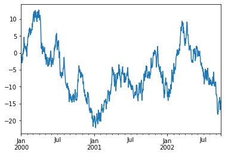

```python
dfData16 = pd.Series(np.random.randn(1000), index=pd.date_range('1/1/2000', periods=1000))
dfData16 = dfData16.cumsum()
dfData16.plot()
```

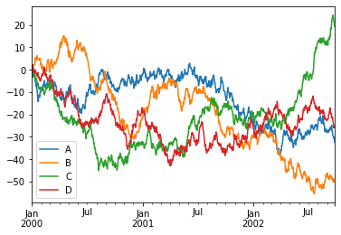

```python
dfData17 = pd.DataFrame(np.random.randn(1000, 4), index=ts.index,
                  columns=['A', 'B', 'C', 'D'])

dfData17 = dfData17.cumsum()

plt.figure(); dfData17.plot(); plt.legend(loc='best')
```

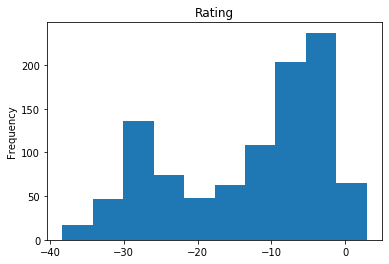

```python
# Plotting a Histogram

dfData17['A'].plot(kind='hist', title='Rating')
```

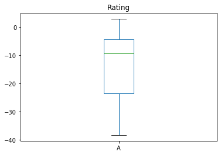

```python
# Plotting a Box

dfData17['A'].plot(kind='box', title='Rating')
```

[figure not shown]

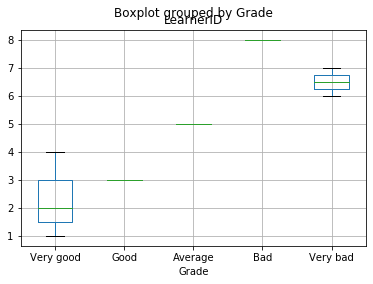

```python
# Creating new Box plot by combining categorical and continuous data

dfData15.boxplot(column='LearnerID', by='Grade')
```

### File IO

#### .csv Files

```python
# Writig to a .csv file

dfData2.to_csv('foo.csv')
```

```python
# Reading from a .csv file

pd.read_csv('foo.csv')
```

|  | Unnamed: 0 | StartValue | StartDate | EndValue | Activity | Action | Response |
| --- | --- | --- | --- | --- | --- | --- | --- |
| 0 | 0 | 1.0 | 2019-01-02 | 1.0 | 3 | test | foo |
| 1 | 1 | 1.0 | 2019-01-02 | 1.0 | 3 | train | foo |
| 2 | 2 | 1.0 | 2019-01-02 | 1.0 | 3 | test | foo |
| 3 | 3 | 1.0 | 2019-01-02 | 1.0 | 3 | train | foo |

#### HDF5

Writing to Reading from HDFStores.

```python
# Writing to a HDF5 Store

dfData1.to_hdf('foo.h5','dfData1')
```

```python
# Reading from a HDF5 Store

pd.read_hdf('foo.h5','dfData1')
```

|  | A | B | C | D |
| --- | --- | --- | --- | --- |
| 2019-01-01 | -0.018862 | 0.506884 | 0.002931 | -0.134582 |
| 2019-01-02 | 0.160282 | 1.263459 | -0.304879 | 0.063906 |
| 2019-01-03 | -0.489581 | -0.140495 | -1.804682 | -0.830140 |
| 2019-01-04 | 0.533439 | 1.288184 | 0.830266 | 0.693305 |
| 2019-01-05 | 0.392912 | -0.643530 | 1.619957 | 0.316364 |
| 2019-01-06 | 0.297479 | -0.755912 | 2.391173 | 2.099550 |

#### Excel

Reading and writing to a MSExcel file.

```python
# Writing to a MSExcel file

dfData2.to_excel('foo.xlsx', sheet_name='Sheet1')
```

```python
# Reading from a MSExcel file

pd.read_excel('foo.xlsx', 'Sheet1', index_col=None, na_values=['NA'])
```

|  | Unnamed: 0 | StartValue | StartDate | EndValue | Activity | Action | Response |
| --- | --- | --- | --- | --- | --- | --- | --- |
| 0 | 0 | 1 | 2019-01-02 | 1 | 3 | test | foo |
| 1 | 1 | 1 | 2019-01-02 | 1 | 3 | train | foo |
| 2 | 2 | 1 | 2019-01-02 | 1 | 3 | test | foo |
| 3 | 3 | 1 | 2019-01-02 | 1 | 3 | train | foo |

## Gotchas

pandas follows the numpy convention of raising an ValueError when trying to convert a value to a Boolean. This is applicable to the Boolean operations: and, or, or not.

INPUT

```
if pd.Series([False, True, False]):
    print("I was true")
```

OUTPUT ValueError: The truth value of a Series is ambiguous. Use a.empty, a.bool() a.item(),a.any() or a.all().

## Index of common pandas DataFrame methods

- `.add()` : Method returns addition of dataframe and other, element-wise (binary operator add)
- `.astype()` : Method converts the data types in a Series
- `.axes()` : Method returns a list representing the axes of the DataFrame
- `.between()` : Method extracts rows where a column value falls in between a predefined range
- `.columns()` : Method is an alternative attribute to change the coloumn name
- `.columns()` : Method returns the column labels of the DataFrame
- `.copy()` : Method creates an independent copy of a pandas object
- `.div()` : Method returns floating division of dataframe and other, element-wise (binary operator truediv)
- `.drop()` : Method is used to delete rows or columns from a DataFrame
- `.drop_duplicates()` : Method is an alternative option to identifying duplicate rows and removing them through filtering
- `.dropna()` : Method allows the user to analyze and drop Rows/Columns with Null values in different ways
- `.dtypes()` : Method returns a Series with the data type of each column. The result’s index is the original DataFrame’s columns
- `.duplicated()` : Method creates a Boolean Series and uses it to extract rows that have duplicate values
- `.fillna()` : Method manages and let the user replace NaN values with some value of their own
- `.iloc[]` : Method retrieves rows based on index position
- `.index()` : Method returns index (row labels) of the DataFrame
- `.insert()` : Method inserts a column into a DataFrame
- `.isin()` : Method extracts rows from a DataFrame where a column value exists in a predefined collection
- `.isnull()` : Method creates a Boolean Series for extracting rows with null values
- `.ix[]` : Method retrieves DataFrame rows based on either index label or index position. This method combines the best features of the .loc[] and .iloc[] methods
- `.loc[]` : Method retrieves rows based on index label
- `.mul()` : Method returns multiplication of dataframe and other, element-wise (binary operator mul)
- `.ndim()` : Method returns an ‘int’ representing the number of axes / array dimensions.
- `.nlargest()` : Method pulls out the rows with the largest values in a column
- `.notnull()` : Method creates a Boolean Series for extracting rows with non-null values
- `.nsmallest()` : Method pulls out the rows with the smallest values in a column
- `.nunique()` : Method returns count of the unique values in the dataframe
- `.pop()` : Method is used to delete rows or columns from a DataFrame
- `.query()` : Method is an alternate string-based syntax for extracting a subset from a DataFrame
- `.rank()` : Values in a Series can be ranked in order with this method
- `.rename()` : Method is called on a DataFrame to change the names of the index labels or column names
- `.reset_index()` : Method resets index of a Data Frame. This method sets a list of integer ranging from 0 to length of data as index
- `.sample()` : Method pulls out a random sample of rows or columns from a DataFrame
- `.set_index()` : Method sets the DataFrame index (row labels) using one or more existing columns
- `.shape()` : Method returns a tuple representing the dimensionality of the DataFrame
- `.sort_index()` : Method sorts the values in a DataFrame based on their index positions or labels instead of their values but sometimes a data frame is made out of two or more data frames and hence later index can be changed using this method
- `.sort_values()- Set1, Set2` : Method sorts a data frame in Ascending or Descending order of passed Column
- `.unique()` : Method extracts the unique values in the dataframe
- `.value_counts()` : Method counts the number of times each unique value occurs within the Series
- `.values()` : Method returns a Numpy representation of the DataFrame i.e. only the values in the DataFrame will be returned, the axes labels will be removed
- `.where()` : Method is used to check a Data Frame for one or more condition and return the result accordingly. By default, the rows not satisfying the condition are filled with NaN value

## References

- https://pandas.pydata.org/
- https://pbpython.com/
- https://towardsdatascience.com/a-guide-to-pandas-and-matplotlib-for-data-exploration-56fad95f951c
- https://www.geeksforgeeks.org/python-pandas-dataframe/
- https://towardsdatascience.com/21-pandas-operations-for-absolute-beginners-5653e54f4cda
- https://www.learndatasci.com/tutorials/python-pandas-tutorial-complete-introduction-for-beginners/
- https://www.shanelynn.ie/select-pandas-dataframe-rows-and-columns-using-iloc-loc-and-ix/
- https://www.dataquest.io/blog/tutorial-time-series-analysis-with-pandas/
- https://www.tutorialspoint.com/python_pandas/index.htm
- https://jakevdp.github.io/PythonDataScienceHandbook/

# Numerical Methods using Python (scipy)

## Overview

The core Python language (including the standard libraries) provide enough functionality to carry out computational research tasks. However, there are dedicated (third-party) Python libraries that provide extended functionality which

- provide numerical tools for frequently occurring tasks
- which are convenient to use
- and are more efficient in terms of CPU time and memory requirements than using the code Python functionality alone.

We list three such modules in particular:

- The `numpy` module provides a data type specialised for “number crunching” of vectors and matrices (this is the `array` type provided by “`numpy`” as introduced in above, and linear algebra tools.
- The `matplotlib` package (also knows as `pylab`) provides plotting and visualisation capabilities (see Visualising Data) and the
- `scipy` package (SCIentific PYthon) which provides a multitude of numerical algorithms and which is introduced in this chapter.

Many of the numerical algorithms available through `scipy` and `numpy` are provided by established compiled libraries which are often written in Fortran or C. They will thus execute much faster than pure Python code (which is interpreted). As a rule of thumb, we expect compiled code to be two orders of magnitude faster than pure Python code.

You can use the help function for each numerical method to find out more about the source of the implementation.

## SciPy

`Scipy` is built on `numpy`. All functionality from `numpy` seems to be available in `scipy` as well. For example, instead of

```python
import numpy
x = numpy.arange(0, 10, 0.1)
y = numpy.sin(x)
```

we can therefor also use

```python
import scipy as s
x = s.arange(0, 10, 0.1)
y = s.sin(x)
```

First we need to import `scipy`:

```python
import scipy
```

The `scipy` package provides information about its own structure when we use the help command:

```
help(scipy)
```

The output is very long, so we're showing just a part of it here:

```
stats       --- Statistical Functions [*]
sparse      --- Sparse matrix [*]
lib         --- Python wrappers to external libraries [*]
linalg      --- Linear algebra routines [*]
signal      --- Signal Processing Tools [*]
misc        --- Various utilities that don't have another home.
interpolate --- Interpolation Tools [*]
optimize    --- Optimization Tools [*]
cluster     --- Vector Quantization / Kmeans [*]
fftpack     --- Discrete Fourier Transform algorithms [*]
io          --- Data input and output [*]
integrate   --- Integration routines [*]
lib.lapack  --- Wrappers to LAPACK library [*]
special     --- Special Functions [*]
lib.blas    --- Wrappers to BLAS library [*]
  [*] - using a package requires explicit import (see pkgload)
```

If we are looking for an algorithm to integrate a function, we might explore the `integrate` package:

```python
import scipy.integrate

scipy.integrate?
```

produces:

```
=============================================
Integration and ODEs (:mod:`scipy.integrate`)
=============================================

.. currentmodule:: scipy.integrate

Integrating functions, given function object
============================================

.. autosummary::
   :toctree: generated/

   quad          -- General purpose integration
   dblquad       -- General purpose double integration
   tplquad       -- General purpose triple integration
   nquad         -- General purpose n-dimensional integration
   fixed_quad    -- Integrate func(x) using Gaussian quadrature of order n
   quadrature    -- Integrate with given tolerance using Gaussian quadrature
   romberg       -- Integrate func using Romberg integration
   quad_explain  -- Print information for use of quad
   newton_cotes  -- Weights and error coefficient for Newton-Cotes integration
   IntegrationWarning -- Warning on issues during integration

Integrating functions, given fixed samples
==========================================

.. autosummary::
   :toctree: generated/

   trapz         -- Use trapezoidal rule to compute integral.
   cumtrapz      -- Use trapezoidal rule to cumulatively compute integral.
   simps         -- Use Simpson's rule to compute integral from samples.
   romb          -- Use Romberg Integration to compute integral from
                 -- (2**k + 1) evenly-spaced samples.

.. seealso::

   :mod:`scipy.special` for orthogonal polynomials (special) for Gaussian
   quadrature roots and weights for other weighting factors and regions.

Integrators of ODE systems
==========================

.. autosummary::
   :toctree: generated/

   odeint        -- General integration of ordinary differential equations.
   ode           -- Integrate ODE using VODE and ZVODE routines.
   complex_ode   -- Convert a complex-valued ODE to real-valued and integrate.
```

The following sections show examples which demonstrate how to employ the algorithms provided by `scipy`.

## Numerical integration

Scientific Python provides a number of integration routines. A general purpose tool to solve integrals *I* of the kind

$$I=\int_a^b f(x) \mathrm{d} x$$

is provided by the `quad()` function of the `scipy.integrate` module.

It takes as input arguments the function *f*(*x*) to be integrated (the “integrand”), and the lower and upper limits *a* and *b*. It returns two values (in a tuple): the first one is the computed results and the second one is an estimation of the numerical error of that result.

Here is an example: which produces this output:

```python
from math import cos, exp, pi
from scipy.integrate import quad

# function we want to integrate
def f(x):
    return exp(cos(-2 * x * pi)) + 3.2

# call quad to integrate f from -2 to 2
res, err = quad(f, -2, 2)

print("The numerical result is {:f} (+-{:g})"
    .format(res, err))
```

```
The numerical result is 17.864264 (+-1.55113e-11)
```

Note that `quad()` takes optional parameters `epsabs` and `epsrel` to increase or decrease the accuracy of its computation. (Use `help(quad)` to learn more.) The default values are `epsabs=1.5e-8` and `epsrel=1.5e-8`. For the next exercise, the default values are sufficient.

### Exercise: integrate a function

1. Using scipy’s `quad` function, write a program that solves the following integral numerically: $I = \int _0^1\cos(2\pi x) dx$.
2. Find the analytical integral and compare it with the numerical solution.
3. Why is it important to have an estimate of the accuracy (or the error) of the numerical integral?

### Exercise: plot before you integrate

It is good practice to plot the integrand function to check whether it is “well behaved” before you attempt to integrate. Singularities (i.e. $x$ values where the $f(x)$ tends towards minus or plus infinity) or other irregular behaviour (such as $f(x)=\sin(\frac{1}{x}$) close to $x = 0$ are difficult to handle numerically.

1. Write a function with name `plotquad` which takes the same arguments as the quad command (*i.e.* $f$, $a$ and $b$) and which
- (i) creates a plot of the integrand $f(x)$ and
- (ii) computes the integral numerically using the `quad` function. The return values should be as for the `quad` function.

## Solving ordinary differential equations

To solve an ordinary differential equation of the type $$\frac{\mathrm{d}y}{\mathrm{d}t}(t) = f(y,t)$$

with a given $y(t_0)=y_0$, we can use `scipy`’s `odeint` function. Here is a (self explaining) example program (`useodeint.py`) to find

$$y(t) \quad \mathrm{for}\quad t\in[0,2]$$

given this differential equation: $$\frac{\mathrm{d}y}{\mathrm{d}t}(t) = -2yt \quad \mathrm{with} \quad y(0)=1.$$

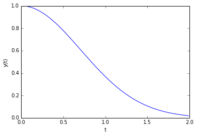

```python
%matplotlib inline
from scipy.integrate import odeint
import numpy as N

def f(y, t):
    """this is the rhs of the ODE to integrate, i.e. dy/dt=f(y,t)"""
    return -2 * y * t

y0 = 1             # initial value
a = 0              # integration limits for t
b = 2

t = N.arange(a, b, 0.01)  # values of t for
                          # which we require
                          # the solution y(t)
y = odeint(f, y0, t)  # actual computation of y(t)

import pylab          # plotting of results
pylab.plot(t, y)
pylab.xlabel('t'); pylab.ylabel('y(t)')
```

The `odeint` command takes a number of optional parameters to change the default error tolerance of the integration (and to trigger the production of extra debugging output). Use the help command to explore these:

```
help(scipy.integrate.odeint)
```

will show:

```
Help on function odeint in module scipy.integrate.odepack:

odeint(func, y0, t, args=(), Dfun=None, col_deriv=0, full_output=0, ml=None, mu=None, rtol=None, atol=None, tcrit=None, h0=0.0, hmax=0.0, hmin=0.0, ixpr=0, mxstep=0, mxhnil=0, mxordn=12, mxords=5, printmessg=0)
    Integrate a system of ordinary differential equations.

    Solve a system of ordinary differential equations using lsoda from the
    FORTRAN library odepack.

    Solves the initial value problem for stiff or non-stiff systems
    of first order ode-s::

        dy/dt = func(y, t0, ...)

    where y can be a vector.

    *Note*: The first two arguments of ``func(y, t0, ...)`` are in the
    opposite order of the arguments in the system definition function used
    by the `scipy.integrate.ode` class.

    Parameters
    ----------
    func : callable(y, t0, ...)
        Computes the derivative of y at t0.
    y0 : array
        Initial condition on y (can be a vector).
    t : array
        A sequence of time points for which to solve for y.  The initial
        value point should be the first element of this sequence.
    args : tuple, optional
        Extra arguments to pass to function.
    Dfun : callable(y, t0, ...)
        Gradient (Jacobian) of `func`.
    col_deriv : bool, optional
        True if `Dfun` defines derivatives down columns (faster),
        otherwise `Dfun` should define derivatives across rows.
    full_output : bool, optional
        True if to return a dictionary of optional outputs as the second output
    printmessg : bool, optional
        Whether to print the convergence message

    Returns
    -------
    y : array, shape (len(t), len(y0))
        Array containing the value of y for each desired time in t,
        with the initial value `y0` in the first row.
    infodict : dict, only returned if full_output == True
        Dictionary containing additional output information

        =======  ============================================================
        key      meaning
        =======  ============================================================
        'hu'     vector of step sizes successfully used for each time step.
        'tcur'   vector with the value of t reached for each time step.
                 (will always be at least as large as the input times).
        'tolsf'  vector of tolerance scale factors, greater than 1.0,
                 computed when a request for too much accuracy was detected.
        'tsw'    value of t at the time of the last method switch
                 (given for each time step)
        'nst'    cumulative number of time steps
        'nfe'    cumulative number of function evaluations for each time step
        'nje'    cumulative number of jacobian evaluations for each time step
        'nqu'    a vector of method orders for each successful step.
        'imxer'  index of the component of largest magnitude in the
                 weighted local error vector (e / ewt) on an error return, -1
                 otherwise.
        'lenrw'  the length of the double work array required.
        'leniw'  the length of integer work array required.
        'mused'  a vector of method indicators for each successful time step:
                 1: adams (nonstiff), 2: bdf (stiff)
        =======  ============================================================

    Other Parameters
    ----------------
    ml, mu : int, optional
        If either of these are not None or non-negative, then the
        Jacobian is assumed to be banded.  These give the number of
        lower and upper non-zero diagonals in this banded matrix.
        For the banded case, `Dfun` should return a matrix whose
        rows contain the non-zero bands (starting with the lowest diagonal).
        Thus, the return matrix `jac` from `Dfun` should have shape
        ``(ml + mu + 1, len(y0))`` when ``ml >=0`` or ``mu >=0``.
        The data in `jac` must be stored such that ``jac[i - j + mu, j]``
        holds the derivative of the `i`th equation with respect to the `j`th
        state variable.  If `col_deriv` is True, the transpose of this
        `jac` must be returned.
    rtol, atol : float, optional
        The input parameters `rtol` and `atol` determine the error
        control performed by the solver.  The solver will control the
        vector, e, of estimated local errors in y, according to an
        inequality of the form ``max-norm of (e / ewt) <= 1``,
        where ewt is a vector of positive error weights computed as
        ``ewt = rtol * abs(y) + atol``.
        rtol and atol can be either vectors the same length as y or scalars.
        Defaults to 1.49012e-8.
    tcrit : ndarray, optional
        Vector of critical points (e.g. singularities) where integration
        care should be taken.
    h0 : float, (0: solver-determined), optional
        The step size to be attempted on the first step.
    hmax : float, (0: solver-determined), optional
        The maximum absolute step size allowed.
    hmin : float, (0: solver-determined), optional
        The minimum absolute step size allowed.
    ixpr : bool, optional
        Whether to generate extra printing at method switches.
    mxstep : int, (0: solver-determined), optional
        Maximum number of (internally defined) steps allowed for each
        integration point in t.
    mxhnil : int, (0: solver-determined), optional
        Maximum number of messages printed.
    mxordn : int, (0: solver-determined), optional
        Maximum order to be allowed for the non-stiff (Adams) method.
    mxords : int, (0: solver-determined), optional
        Maximum order to be allowed for the stiff (BDF) method.

    See Also
    --------
    ode : a more object-oriented integrator based on VODE.
    quad : for finding the area under a curve.

    Examples
    --------
    The second order differential equation for the angle `theta` of a
    pendulum acted on by gravity with friction can be written::

        theta''(t) + b*theta'(t) + c*sin(theta(t)) = 0

    where `b` and `c` are positive constants, and a prime (') denotes a
    derivative.  To solve this equation with `odeint`, we must first convert
    it to a system of first order equations.  By defining the angular
    velocity ``omega(t) = theta'(t)``, we obtain the system::

        theta'(t) = omega(t)
        omega'(t) = -b*omega(t) - c*sin(theta(t))

    Let `y` be the vector [`theta`, `omega`].  We implement this system
    in python as:

    >>> def pend(y, t, b, c):
    ...     theta, omega = y
    ...     dydt = [omega, -b*omega - c*np.sin(theta)]
    ...     return dydt
    ...

    We assume the constants are `b` = 0.25 and `c` = 5.0:

    >>> b = 0.25
    >>> c = 5.0

    For initial conditions, we assume the pendulum is nearly vertical
    with `theta(0)` = `pi` - 0.1, and it initially at rest, so
    `omega(0)` = 0.  Then the vector of initial conditions is

    >>> y0 = [np.pi - 0.1, 0.0]

    We generate a solution 101 evenly spaced samples in the interval
    0 <= `t` <= 10.  So our array of times is:

    >>> t = np.linspace(0, 10, 101)

    Call `odeint` to generate the solution.  To pass the parameters
    `b` and `c` to `pend`, we give them to `odeint` using the `args`
    argument.

    >>> from scipy.integrate import odeint
    >>> sol = odeint(pend, y0, t, args=(b, c))

    The solution is an array with shape (101, 2).  The first column
    is `theta(t)`, and the second is `omega(t)`.  The following code
    plots both components.

    >>> import matplotlib.pyplot as plt
    >>> plt.plot(t, sol[:, 0], 'b', label='theta(t)')
    >>> plt.plot(t, sol[:, 1], 'g', label='omega(t)')
    >>> plt.legend(loc='best')
    >>> plt.xlabel('t')
    >>> plt.grid()
    >>> plt.show()
```

### Exercise: using `odeint`

- Write a program that computes the solution *y*(*t*) of this ODE using the `odeint` algorithm:

  $$\frac{\mathrm{d}y}{\mathrm{d}t} = -\exp(-t)(10\sin(10t)+\cos(10t))$$ from $t=0$ to $t = 10$. The initial value is $y(0)=1$.
- You should display the solution graphically at points $t=0$, $t=0.01$, $t=0.02$, ..., $t=9.99$, $t=10$.

## Root finding

If you try to find a $x$ such that $$f(x)=0$$ then this is called *root finding*. Note that problems like $g(x)=h(x)$ fall in this category as you can rewrite them as $f(x)=g(x)−h(x)=0$.

A number of root finding tools are available in `scipy`’s `optimize` module.

### Root finding using the bisection method

First we introduce the `bisect` algorithm which is (i) robust and (ii) slow but conceptually very simple.

Suppose we need to compute the roots of *f*(*x*)=*x*<sup>3</sup> − 2*x*<sup>2</sup>. This function has a (double) root at *x* = 0 (this is trivial to see) and another root which is located between *x* = 1.5 (where *f*(1.5)= − 1.125) and *x* = 3 (where *f*(3)=9). It is pretty straightforward to see that this other root is located at *x* = 2. Here is a program that determines this root numerically:

```python
from scipy.optimize import bisect

def f(x):
    """returns f(x)=x^3-2x^2. Has roots at
    x=0 (double root) and x=2"""
    return x ** 3 - 2 * x ** 2

# main program starts here
x = bisect(f, 1.5, 3, xtol=1e-6)

print("The root x is approximately x=%14.12g,\n"
      "the error is less than 1e-6." % (x))
print("The exact error is %g." % (2 - x))
```

```
The root x is approximately x= 2.00000023842,
the error is less than 1e-6.
The exact error is -2.38419e-07.
```

The `bisect()` method takes three compulsory arguments: (i) the function *f*(*x*), (ii) a lower limit *a* (for which we have chosen 1.5 in our example) and (ii) an upper limit *b* (for which we have chosen 3). The optional parameter `xtol` determines the maximum error of the method.

One of the requirements of the bisection method is that the interval [*a*, *b*] has to be chosen such that the function is either positive at *a* and negative at *b*, or that the function is negative at *a* and postive at *b*. In other words: *a* and *b* have to enclose a root.

### Exercise: root finding using the bisect method

1. Write a program with name `sqrttwo.py` to determine an approximation of $\sqrt{2}$ by finding a root *x* of the function $f(x)=2 − x^2$ using the bisection algorithm. Choose a tolerance for the approximation of the root of 10<sup>−8</sup>.
2. Document your choice of the initial bracket $[a, b]$ for the root: which values have you chosen for *a* and for *b* and why?
3. Study the results:
   - Which value for the root *x* does the bisection algorithm return?
   - Compute the value of $\\sqrt{2}$ using `math.sqrt(2)` and compare this with the approximation of the root. How big is the absolute error of *x*? How does this compare with `xtol`?

### Root finding using the `fsolve` funcion

A (often) better (in the sense of “more efficient”) algorithm than the bisection algorithm is implemented in the general purpose `fsolve()` function for root finding of (multidimensional) functions. This algorithm needs only one starting point close to the suspected location of the root (but is not garanteed to converge).

Here is an example:

```python
from scipy.optimize import fsolve

def f(x):
    return x ** 3 - 2 * x ** 2

x = fsolve(f, 3)           # one root is at x=2.0

print("The root x is approximately x=%21.19g" % x)
print("The exact error is %g." % (2 - x))
```

```
The root x is approximately x= 2.000000000000006661
The exact error is -6.66134e-15.
```

The return value[6] of `fsolve` is a numpy array of length *n* for a root finding problem with *n* variables. In the example above, we have *n* = 1.

## Interpolation

Given a set of *N* points $(x_i, y_i)$ with $i = 1, 2, …N$, we sometimes need a function $\hat{f}(x)$ which returns $y_i = f(x_i)$ where $x == x_i$, and which in addition provides some interpolation of the data $(x_i, y_i)$ for all $x$.

The function `y0 = scipy.interpolate.interp1d(x,y,kind=’nearest’)` does this interpolation based on splines of varying order. Note that the function `interp1d` returns *a function* `y0` which will then interpolate the x-y data for any given $x$ when called as $y0(x)$.

The code below demonstrates this, and shows the different interpolation kinds.

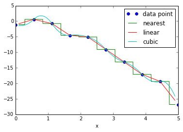

```python
import numpy as np
import scipy.interpolate
import pylab

def create_data(n):
    """Given an integer n, returns n data points
    x and values y as a numpy.array."""
    xmax = 5.
    x = np.linspace(0, xmax, n)
    y = - x**2
    #make x-data somewhat irregular
    y += 1.5 * np.random.normal(size=len(x))
    return x, y

#main program
n = 10
x, y = create_data(n)

#use finer and regular mesh for plot
xfine = np.linspace(0.1, 4.9, n * 100)
#interpolate with piecewise constant function (p=0)
y0 = scipy.interpolate.interp1d(x, y, kind='nearest')
#interpolate with piecewise linear func (p=1)
y1 = scipy.interpolate.interp1d(x, y, kind='linear')
#interpolate with piecewise constant func (p=2)
y2 = scipy.interpolate.interp1d(x, y, kind='quadratic')

pylab.plot(x, y, 'o', label='data point')
pylab.plot(xfine, y0(xfine), label='nearest')
pylab.plot(xfine, y1(xfine), label='linear')
pylab.plot(xfine, y2(xfine), label='cubic')
pylab.legend()
pylab.xlabel('x')
```